# Final Fundamentos 2023

Lauro Reyes Rosas 000213245 & Sara Luz Valenzuela Camacho 000204535

2023-12-05

Un reporte con las respuestas se deberá enviar por correo electrónico a más tardar el martes 5 a las 21:00 horas.

Instrucciones:

- En las siguientes preguntas describe tus procedimientos y escribe las respuestas explícitamente (que no haya necesidad de correr código para obtenerlas).
- Incluye el código.
- No está permitido discutir el exámen fuera de su equipo.
- Para dudas (que no deben incluir info. de la respuesta) se preguntará en el canvas del grupo.
- Consideren el material de visualización al hacer sus gráficas y reportar sus resultados.

## 1. Pruebas de hipótesis

1.1 De acuerdo a una encuesta en EUA, 26% de los residentes adultos de Illinois han terminado la preparatoria. Un investigador sospecha que este porcentaje es menor en un condado particular del estado. Obtiene una muestra aleatoria de dicho condado y encuentra que 69 de 310 personas en la muestra han completado la preparatoria. Estos resultados soportan su hipótesis? (describe tu elección de prueba de hipótesis, valor p y conclusión).

```r
# Prueba de Wald
p_hat <- 69 / 310
ee <- sqrt(p_hat * (1 - p_hat) / 310)
w <- (p_hat - 0.26) / ee
p_value <- 2 * (1 - pnorm(abs(w)))
cat("p-value: ",p_value)
```

```
## p-value:  0.1132347
```

- **Tenemos evidencia baja de que el porcentaje es menor en el condado del estudio ya que el p value es .113, por lo tanto no podemos rechazar la hipótesis nula**

1.2 Mendel criaba chícharos de semillas lisas amarillas y de semillas corrugadas verdes. Éstas daban lugar a 4 tipos de descendientes: amarrillas lisas, amarillas corrugadas, verdes lisas y verdes corrugadas. El número de cada una es multinomial con parámetro $p=(p_1, p_2, p_3, p_4)$. De acuerdo a su teoría de herencia este vector de probabilidades es:
$$p=(9/16,3/16,3/16,1/16)$$
A lo largo de $n=556$ experimentos observó $x=(315,101,108,32)$. Utiliza la prueba de cociente de verosimilitudes para probar $H_0:p=p_0$ contra $H_0:p\ne p_0$.

```r
p_0 <- c(9/16, 3/16, 3/16, 1/16)
x <- c(315, 101, 108, 32)
n <- 556
H0 <- dmultinom(x, size = n, prob = p_0, log = TRUE)
# MLE
p_hat <- x / n
H1 <- dmultinom(x, size = n, prob = p_hat, log = TRUE)
lambda <- 2 * (H1 - H0)
p_value <- pchisq(lambda, df = 4, lower.tail = FALSE)
cat("p-value: ",p_value)
```

```
## p-value:  0.9758469
```

**Valor p es bastante alto, no se puede rechazar la hipótesis nula**

1.3. Sean $X_1, ...X_n \sim Poisson(\lambda)$,

- Sea $\lambda_0>0$. ¿Cuál es la prueba Wald para $H_0: \lambda = \lambda_0, H_1: \lambda \neq \lambda_0$

```r
wald_poisson <- function(x, lambda_0){
  lambda_1 <- mean(x)
  se_lambda <- sqrt(lambda_1 / length(x))
  z <- (lambda_1 - lambda_0) / se_lambda
  p_value <- 2 * pnorm(-abs(z))
  p_value
}
```

- Si $\lambda_0=1$, $n=20$ y $\alpha = 0.05$. Simula $X_1, ...X_n \sim Poisson(\lambda_0)$ y realiza la prueba Wald, repite 1000 veces y registra el porcentaje de veces que rechazas $H_0$, qué tan cerca te queda el error del tipo 1 de $0.05$?

```r
set.seed(4)
lambda_0 <- 1
n <- 20
alpha <- 0.05
N <- 1000
simulations <- numeric(N)

for (i in 1:N) {
    simulations[i] <- wald_poisson(rpois(n,lambda_0),lambda_0)
}

cat("Error tipo 1: ",mean(simulations < alpha))
```

```
## Error tipo 1:  0.047
```

**Proporción de rechazos de la hipótesis nula es cercana a alpha sugiriendo que la prueba de Wald está calibrada.**

## 2. Relación entre bootstrap e inferencia bayesiana

Consideremos el caso en que tenemos una única observación $x$ proveniente de una distribución normal

$$x \sim N(\theta, 1)$$

Supongamos ahora que elegimos una distribución inicial Normal.

$$\theta \sim N(0, \tau)$$

dando lugar a la distribución posterior (como vimos en la tarea)

$$\theta|x \sim N\bigg(\frac{x}{1 +
1/\tau}, \frac{1}{1+1/\tau}\bigg)$$

Ahora, entre mayor $\tau$, más se concentra la posterior en el estimador de máxima verosimilitud $\hat{\theta}=x$. En el límite, cuando $\tau \to \infty$ obtenemos una inicial no-informativa (constante) y la distribución posterior

$$\theta|x \sim N(x,1)$$

Esta posterior coincide con la distribución de bootstrap paramétrico en que generamos valores $x^*$ de $N(x,1)$, donde $x$ es el estimador de máxima verosimilitud.

Lo anterior se cumple debido a que utilizamos un ejemplo Normal pero también se cumple aproximadamente en otros casos, lo que conlleva a una correspondencia entre el bootstrap paramétrico y la inferencia bayesiana. En este caso, la distribución bootstrap representa (aproximadamente) una distribución posterior no-informartiva del parámetro de interés. Mediante la perturbación en los datos el bootstrap aproxima el efecto bayesiano de perturbar los parámetros con la ventaja de ser más simple de implementar (en muchos casos).  
*Los detalles se pueden leer en *The Elements of Statistical Learning* de Hastie y Tibshirani.

Comparemos los métodos en otro problema con el fin de apreciar la similitud en los procedimientos:

Supongamos $x_1,...,x_n \sim N(0, \sigma^2)$, es decir, los datos provienen de una distribución con media cero y varianza desconocida.

En los puntos 2.1 y 2.2 buscamos hacer inferencia del parámetro $\sigma^2$.

2.1 Bootstrap paramétrico.

- Escribe la función de log-verosimilitud y calcula el estimador de máxima verosimilitud para $\sigma^2$. Supongamos que observamos los datos `x` (en la carpeta datos), ¿Cuál es tu estimación de la varianza?

```r
load("data/x.RData")

crear_log_p <- function(x){
  log_p <- function(pars){
    mean = pars[1]
    desv_est = pars[2]
    z <- (x - 0) / desv_est
    log_verosim <- -(log(desv_est) +  0.5 * mean(z^2))
    log_verosim
  }
  log_p
}
log_p <- crear_log_p(x)
res <- optim(c(0, 0.5), log_p, control = list(fnscale = -1, maxit = 1000), method = "Nelder-Mead")
# MLE
est_mle <- res$par[2]^2
sigma_est=mean(x^2)
cat("Sigma estimada: ",sigma_est,"- MLE: ",est_mle)
```

```
## Sigma estimada:  131.291 - MLE:  131.1025
```

- Aproxima el error estándar de la estimación usando **bootstrap paramétrico** y realiza un histograma de las replicaciones bootstrap.

```r
set.seed(4)
simular_modelo <- function(n, media, sigma){
  rnorm(n, media, sigma)
}

rep_boot <- function(rep, crear_log_p, est_mle, n){
  muestra_bootstrap <- simular_modelo(n, 0, sqrt(est_mle))
  log_p_boot <- crear_log_p(muestra_bootstrap)
  # optimizamos
  res_boot <- optim(c(0, 0.5), log_p_boot,
    control = list(fnscale = -1, maxit = 1000), method = "Nelder-Mead")
  try(if(res_boot$convergence != 0) stop("No se alcanzó convergencia."))
  tibble(parametro = "sigma_2", estimador_boot = res_boot$par[2]^2)
}
reps_boot <- map_dfr(1:5000, ~ rep_boot(.x, crear_log_p, est_mle, length(x)), rep = ".id")

ee <- reps_boot %>% summarise(ee_boot = sd(estimador_boot))
cat("Error estándar bootstrap: ",ee$ee_boot)
```

```
## Error estándar bootstrap:  14.89698
```

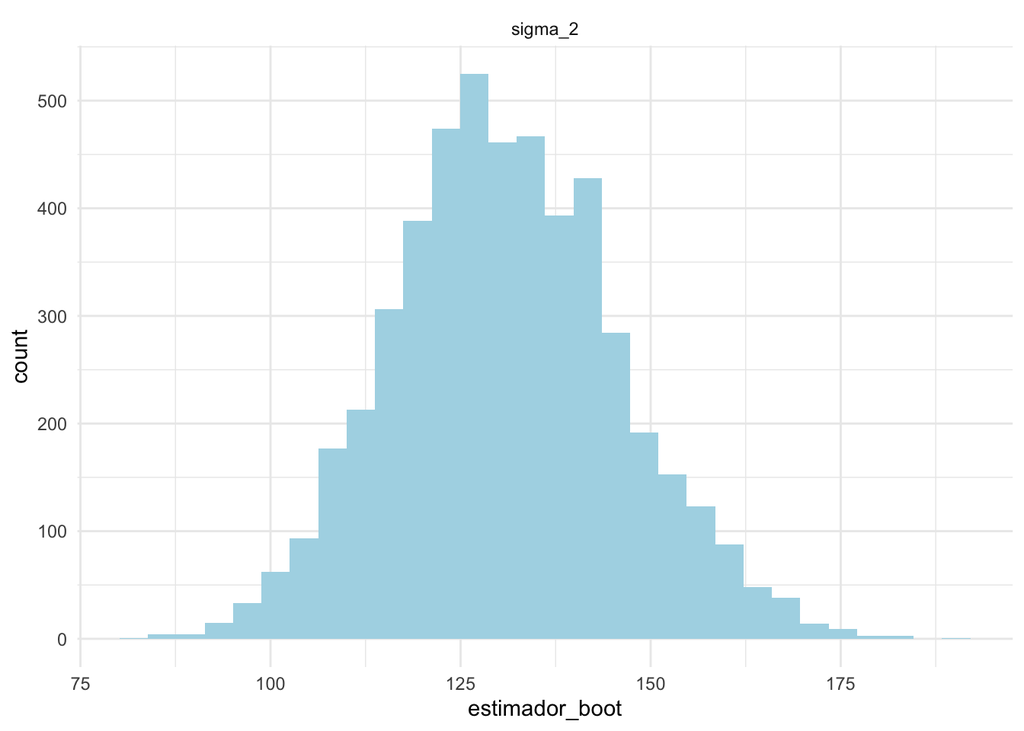

```r
ggplot(reps_boot, aes(x = estimador_boot)) +
  geom_histogram(title = "Replicaciones Bootstrap",fill="lightblue") +facet_wrap(~parametro)+
  theme_minimal()
```

2.2 Análisis bayesiano

- Continuamos con el problema de hacer inferencia de $\sigma^2$. Comienza especificando una inicial Gamma Inversa, justifica tu elección de los parámetros de la distribución inicial y grafica la función de densidad.

**Varianza de la gamma inversa**
$$\sigma^2 = \frac{\beta^2}{{(\alpha-1)}^2 -
(\alpha-2)}\quad for\quad\alpha>2$$
**por lo tanto escojemos** $\alpha$ = 2 **y** $\beta$ = $\hat{\theta}$ **para que la escala de la distribución inicial sea igual a la estimación de máxima verosimilitud de la varianza.**

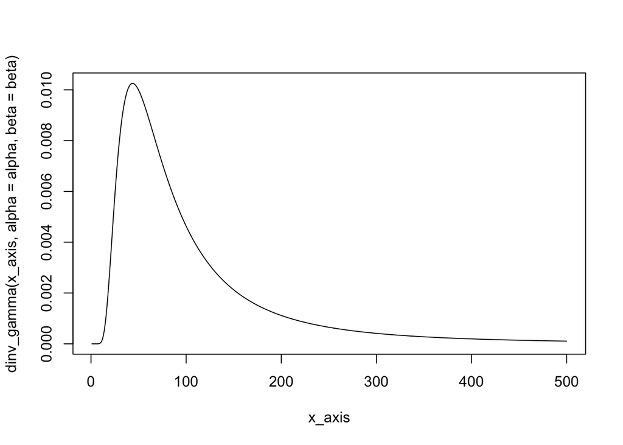

```r
alpha <- 2
beta <- est_mle
dinv_gamma <- function(sigma2, alpha, beta){
  (beta^alpha / gamma(alpha)) * (1/sigma2)^(alpha + 1) * exp(-beta / sigma2)
}

x_axis <- seq(1, 500, 1)
plot(x_axis, dinv_gamma(x_axis, alpha=alpha, beta=beta), type="l")
```

- Calcula analíticamente la distribución posterior. *La verosimilitud es:*

$$L(\sigma^2|y) \propto
(\sigma^2)^{n/2}e^{-\frac{n}{2\sigma^2}[\frac{1}{n}\sum_{i=1}^n(Y_i-\mu)^2]}$$

*La priori es:*

$$p(\sigma^2)=\frac{\beta^\alpha}{\Gamma(\alpha)}(\sigma^2)^{-(\alpha+1)}e^{-\beta/\sigma^2}$$
*para* $\sigma^2>0$

*Por tanto, la posterior es:*

$$p(\sigma^2|y)\propto L(\sigma^2|y)
p(\sigma^2)$$
$$\propto(\sigma^2)^{n/2}e^{-\frac{n}{2\sigma^2}[\frac{1}{n}\sum_{i=1}^n(Y_i-\mu)^2]}(\sigma^2)^{-(\alpha+1)}e^{-\beta/\sigma^2}$$
$$=(\sigma^2)^{-(\alpha+\frac{n}{2}+1)}e^{-\frac{\beta+\frac{n}{2}[\frac{1}{n}\sum_{i=1}^n(Y_i-\mu)^2]}{\sigma^2}}$$

*Por tanto la posteriori es una Inversa gamma con parámetros:*
$$f(\sigma^2 \,|\, x_1, ..., x_n) =
\text{GammaI}\left(\alpha + \frac{n}{2}, \beta +
\frac{1}{2}\sum_{i=1}^{n}(x_i - \mu)^2\right)$$
* Realiza un histograma de simulaciones de la distribución posterior y calcula el error estándar de la distribución.

```r
simulacion_posterior <- function(x, alpha, beta, n){
  alpha_posterior <- alpha + length(x) / 2
  beta_posterior <- beta + sum(x^2) / 2
  posterior <- 1 / rgamma(n=n, shape=alpha_posterior, rate=beta_posterior)
  posterior
}

posterior <- simulacion_posterior(x,alpha, beta, 5000)
ee_posterior <- sd(posterior)
cat("Error estándar de la posterior: ",ee_posterior)
```

```
## Error estándar de la posterior:  15.21675
```

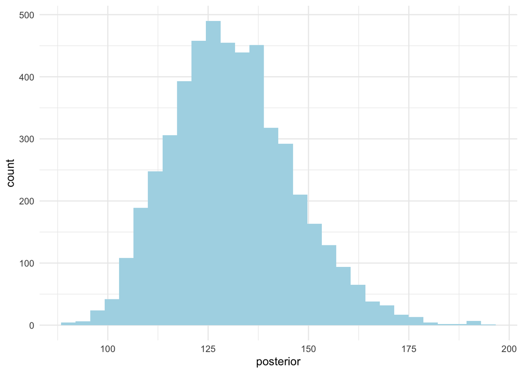

```r
#plot
ggplot(data.frame(posterior), aes(x = posterior)) +
  geom_histogram(fill="lightblue") +
  theme_minimal()
```

- ¿Cómo se comparan tus resultados con los de bootstrap paramétrico?

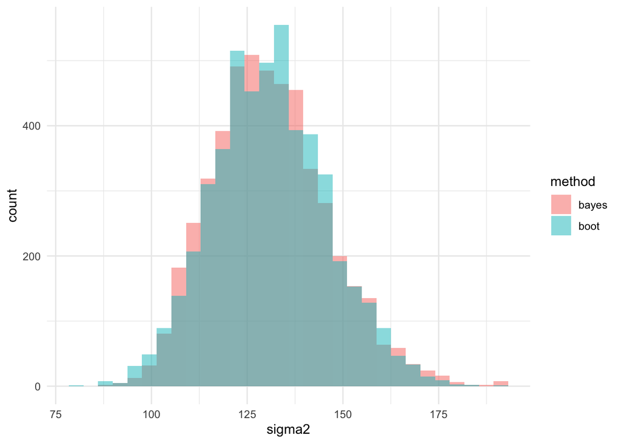

```r
compare_data <- tibble(
    method = rep(c("boot", "bayes"), each = length(posterior)),
    sigma2 = c(reps_boot$estimador_boot, posterior)
)

ggplot(compare_data, aes(x = sigma2, fill = method)) +
  geom_histogram(aes(x = sigma2), bins = 30, alpha = 0.5, position = "identity") +
  theme_minimal()
```

**Observamos que las distribuciones son bastante parecidas, con la distribución posterior mostranddo una ligera inclinación hacia la izquierda**

2.3 Supongamos que ahora buscamos hacer inferencia del parámetro $\tau=log(\sigma)$, ¿cuál es el estimador de máxima verosimilitud?

```r
t_mle <- log(sqrt(est_mle))
```

- Utiliza bootstrap paramétrico para generar un intervalo de confianza del 95% para el parámetro $\tau$ y realiza un histograma de las replicaciones bootstrap.

```r
set.seed(4)
crear_log_p <- function(muestra){
  log(sd(muestra))
}

rep_boot <- function(rep, crear_log_p, est_mle, n){
  muestra_bootstrap <- simular_modelo(n, 0, sqrt(est_mle))
  t_mle <- crear_log_p(muestra_bootstrap)
  tibble(parametro = "tau", estimador_boot = t_mle)
}
reps_boot <- map_dfr(1:5000, ~ rep_boot(.x, crear_log_p, est_mle, length(x)), rep = ".id")

intervalo <- quantile(reps_boot$estimador_boot, c(0.025, 0.975))
print(intervalo)
```

```
##     2.5%    97.5%
## 2.316664 2.543767
```

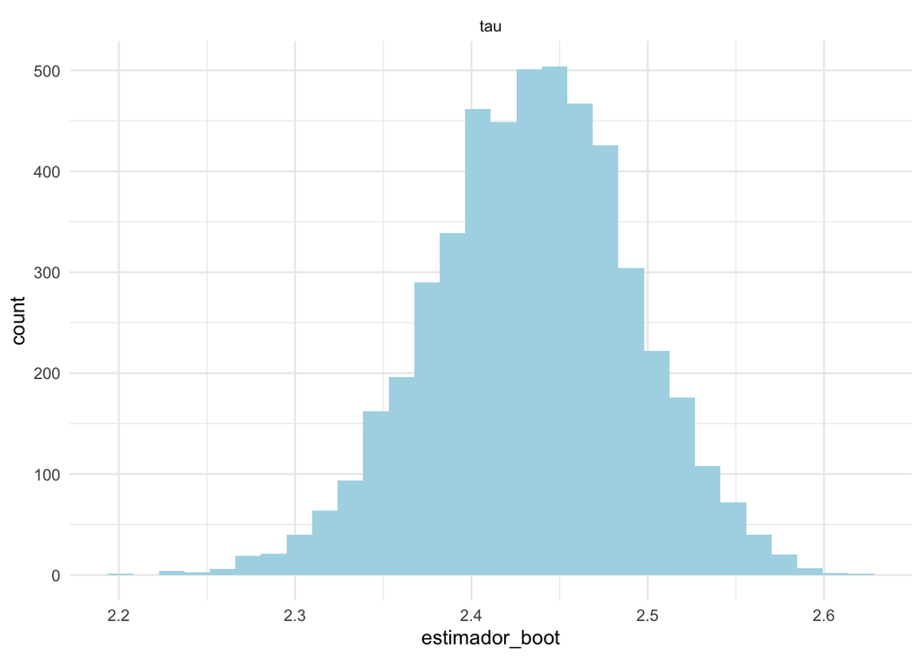

```r
ggplot(reps_boot, aes(x = estimador_boot)) +
  geom_histogram(fill="lightblue") +facet_wrap(~parametro) +
  theme_minimal()
```

- Ahora volvamos a inferencia bayesiana, calcula un intervalo de confianza para $\tau$ y un histograma de la distribución posterior de $\tau$.

```r
simulacion_posterior <- function(x, alpha, beta, n){
  alpha_posterior <- alpha + length(x) / 2
  beta_posterior <- beta + sum(x^2) / 2
  inv_gamma <- 1 / rgamma(n=n, shape=alpha_posterior, rate=beta_posterior)
  posterior <- log(sqrt(inv_gamma))
  posterior
}

posterior_t <- simulacion_posterior(simular_modelo(length(x), 0, sqrt(est_mle)),alpha, beta, 5000)
intervalo_p <- quantile(posterior_t, c(0.025, 0.975))
print(intervalo_p)
```

```
##     2.5%    97.5%
## 2.282117 2.504824
```

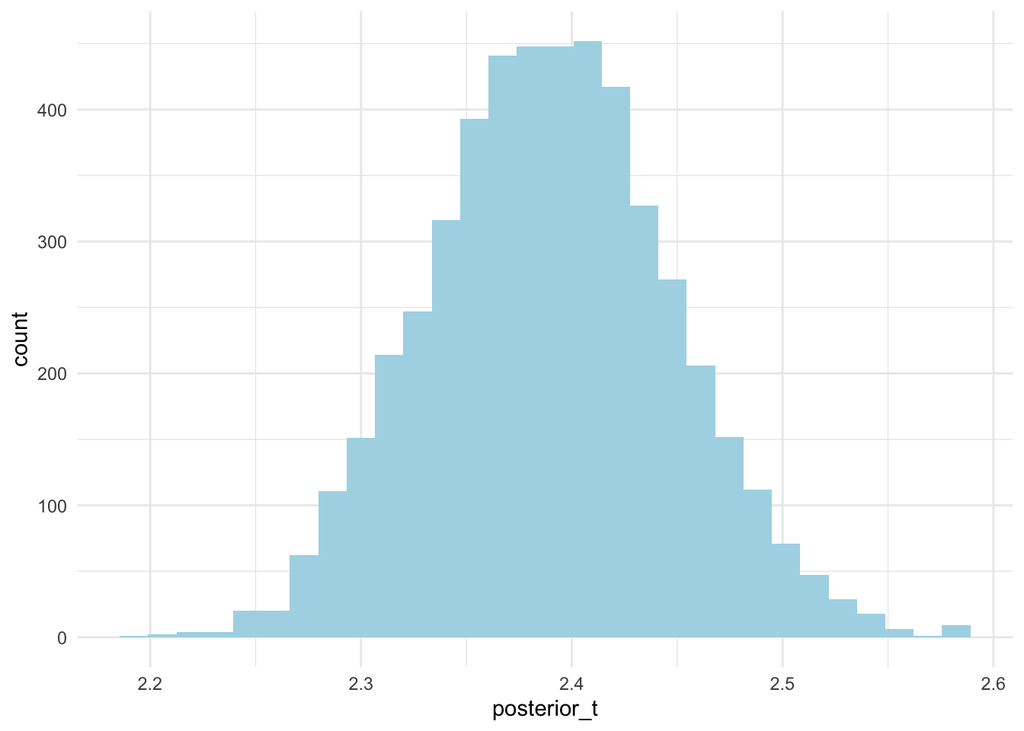

```r
#plot
ggplot(data.frame(posterior_t), aes(x = posterior_t)) +
  geom_histogram(fill="lightblue") +
  theme_minimal()
```

### 3. Bayesiana y regularización

Los datos *pew_research_center_june_elect_wknd_data.dta* tienen información de encuestas realizadas durante la campaña presidencial 2008 de EUA.

```r
poll_data <- foreign::read.dta("data/pew_research_center_june_elect_wknd_data.dta")
```

- Estima el porcentaje de la población de cada estado (excluyendo Alaska, Hawai, y DC) que se considera *very liberal*, utilizando el estimador de máxima verosimilitud.

```r
data <- poll_data %>%
  filter(!state %in% c('alaska', 'hawaii','washington dc')) %>%
  mutate(x = if_else(ideo == 'very liberal', 1, 0, 0)) %>%
  group_by(state) %>%
  summarise(very_liberal = sum(x), n = n(), p = very_liberal/n, .groups="drop")
```

- Grafica en el eje *x* el número de encuestas para cada estado y en el eje *y* la estimación de máxima verosimilitud para *very liberal*. ¿Qué observas?

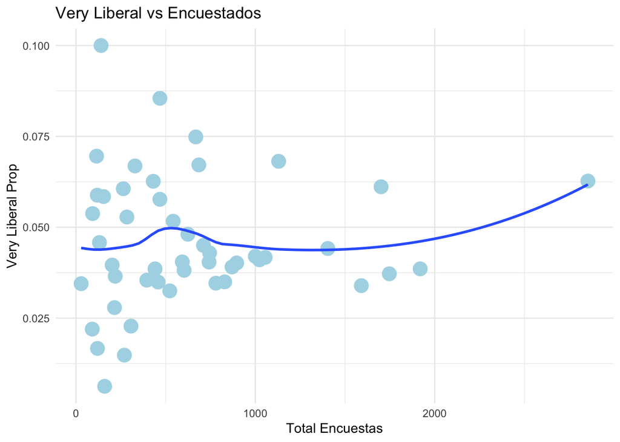

```r
ggplot(data, aes(x = n, y = p)) +
  geom_point(color = 'lightblue', size = 5) +
  geom_smooth(method = "loess", se = FALSE) +
  labs(title = "Very Liberal vs Encuestados",
       x = "Total Encuestas",
       y = "Very Liberal Prop") +
  theme_minimal()
```

- Grafica en el eje *x* el porcentaje de votos que obtuvo Obama en la elección para cada estado y en el eje *y* la estimación de máxima verosimilitud para *very liberal*. ¿Qué observas? (usa los datos *2008ElectionResult.csv*)

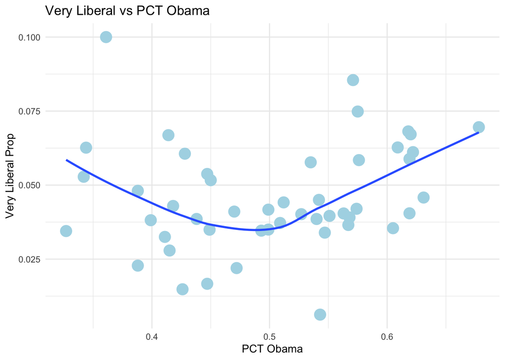

```r
election_result <- read_csv('data/2008ElectionResult.csv')
election_result <- election_result %>%
  mutate(state = tolower(state)) %>%
  inner_join(data %>% select(c('state','p')), by=c("state")) %>%
  rename(very_liberal_estimate = p) %>%
  mutate(vote_Obama_pct = vote_Obama_pct / 100)

ggplot(election_result, aes(x = vote_Obama_pct, y = very_liberal_estimate)) +
  geom_point(color = 'lightblue', size = 5) +
  geom_smooth(method = "loess", se = FALSE) +
  labs(title = "Very Liberal vs PCT Obama",
       x = "PCT Obama",
       y = "Very Liberal Prop") +
  theme_minimal()
```

**En general, la proporción de very liberal aumenta en los extremos tanto izquierda o derecha de la proporción que voto por Obama**

- Estima el mismo porcentaje (*very liberal*) usando inferencia bayesiana, en particular la familia conjugada beta-binomial. Deberás estimar la proporción de manera independiente para cada estado, sin embargo, utilizarás la misma inicial a lo largo de todos: $Beta(8,160)$.
  - Simula de la distribución incial y describe.

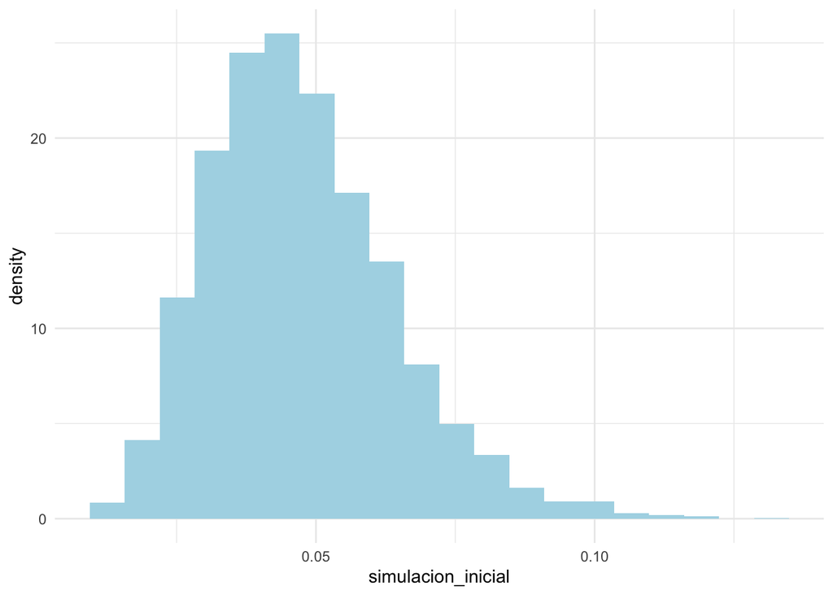

```r
alpha <- 8
beta <- 160
simulacion_inicial <- rbeta(5000, alpha, beta)
ggplot(tibble(simulacion_inicial)) + geom_histogram(aes(x = simulacion_inicial, y = ..density..), bins = 20, fill="lightblue") +
  theme_minimal()
```

**La media es similar al valor de máxima verosimilitud**

- Para dos de los estados: Idaho y Virginia, adicional a calcular la posterior usando las propiedades de la familia conjugada, utiliza Stan para hacer la inferencia, revisa los diagnósticos de convergencia y describe tus observaciones ($\hat{R}$ y $ESS$).

###### posterior

```r
simulacion_posterior <- function(success, obs, alpha, beta, n){
  alpha_posterior <- alpha + success
  beta_posterior <- beta + (obs -success)
  posterior <- rbeta(n,alpha_posterior,beta_posterior)
  posterior
}

posterior_by_state <- tibble(state = character(), posterior = numeric())

for (current_state in unique(data$state)) {
  current_state_data <- filter(data, state == current_state)
  prop_posterior <- simulacion_posterior(current_state_data$very_liberal,current_state_data$n,
    alpha,beta,500
  )
  # Calculate
  mean_value <- mean(prop_posterior)

  posterior_by_state <- bind_rows(posterior_by_state, tibble(state = current_state, posterior = mean_value))
}

posterior_by_state %>% arrange(desc(posterior)) %>%
  kable("html") %>%
  kable_styling("striped", full_width = FALSE)
```

| state | posterior |
| --- | --- |
| oregon | 0.0760042 |
| idaho | 0.0721742 |
| washington | 0.0695112 |
| illinois | 0.0654691 |
| massachusetts | 0.0633453 |
| california | 0.0623206 |
| kansas | 0.0609292 |
| new york | 0.0597669 |
| oklahoma | 0.0592404 |
| vermont | 0.0555749 |
| mississippi | 0.0554418 |
| colorado | 0.0551580 |
| maine | 0.0532358 |
| delaware | 0.0514172 |
| arizona | 0.0509188 |
| utah | 0.0507764 |
| south dakota | 0.0492745 |
| alabama | 0.0485069 |
| rhode island | 0.0470175 |
| minnesota | 0.0456695 |
| ohio | 0.0446721 |
| wyoming | 0.0444930 |
| nevada | 0.0434230 |
| tennessee | 0.0433806 |
| michigan | 0.0428114 |
| maryland | 0.0426410 |
| north carolina | 0.0423468 |
| georgia | 0.0421724 |
| wisconsin | 0.0414925 |
| virginia | 0.0414855 |
| iowa | 0.0407803 |
| new mexico | 0.0405748 |
| louisiana | 0.0401207 |
| new jersey | 0.0399550 |
| texas | 0.0394530 |
| montana | 0.0384958 |
| connecticut | 0.0384749 |
| south carolina | 0.0381024 |
| florida | 0.0380709 |
| indiana | 0.0367823 |
| missouri | 0.0365089 |
| nebraska | 0.0363617 |
| kentucky | 0.0358396 |
| pennsylvania | 0.0350421 |
| north dakota | 0.0343457 |
| arkansas | 0.0315371 |
| new hampshire | 0.0277541 |
| west virginia | 0.0273491 |

##### STAN

```r
archivo_stan <- file.path("./stan/modelo-1.stan")
model_ <- cmdstan_model(archivo_stan)

# Virginia
state_data <- data %>% filter(state == "virginia")
virginia_model <- model_$sample(
  data = list(n=state_data$n,y=state_data$very_liberal),
  chains = 4,
  refresh = 500,
  seed = 1234
)
```

```
## Running MCMC with 4 sequential chains...
##
## Chain 1 Iteration:    1 / 2000 [  0%]  (Warmup)
## Chain 1 Iteration:  500 / 2000 [ 25%]  (Warmup)
## Chain 1 Iteration: 1000 / 2000 [ 50%]  (Warmup)
## Chain 1 Iteration: 1001 / 2000 [ 50%]  (Sampling)
## Chain 1 Iteration: 1500 / 2000 [ 75%]  (Sampling)
## Chain 1 Iteration: 2000 / 2000 [100%]  (Sampling)
## Chain 1 finished in 0.0 seconds.
## Chain 2 Iteration:    1 / 2000 [  0%]  (Warmup)
## Chain 2 Iteration:  500 / 2000 [ 25%]  (Warmup)
## Chain 2 Iteration: 1000 / 2000 [ 50%]  (Warmup)
## Chain 2 Iteration: 1001 / 2000 [ 50%]  (Sampling)
## Chain 2 Iteration: 1500 / 2000 [ 75%]  (Sampling)
## Chain 2 Iteration: 2000 / 2000 [100%]  (Sampling)
## Chain 2 finished in 0.0 seconds.
## Chain 3 Iteration:    1 / 2000 [  0%]  (Warmup)
## Chain 3 Iteration:  500 / 2000 [ 25%]  (Warmup)
## Chain 3 Iteration: 1000 / 2000 [ 50%]  (Warmup)
## Chain 3 Iteration: 1001 / 2000 [ 50%]  (Sampling)
## Chain 3 Iteration: 1500 / 2000 [ 75%]  (Sampling)
## Chain 3 Iteration: 2000 / 2000 [100%]  (Sampling)
## Chain 3 finished in 0.0 seconds.
## Chain 4 Iteration:    1 / 2000 [  0%]  (Warmup)
## Chain 4 Iteration:  500 / 2000 [ 25%]  (Warmup)
## Chain 4 Iteration: 1000 / 2000 [ 50%]  (Warmup)
## Chain 4 Iteration: 1001 / 2000 [ 50%]  (Sampling)
## Chain 4 Iteration: 1500 / 2000 [ 75%]  (Sampling)
## Chain 4 Iteration: 2000 / 2000 [100%]  (Sampling)
## Chain 4 finished in 0.0 seconds.
##
## All 4 chains finished successfully.
## Mean chain execution time: 0.0 seconds.
## Total execution time: 0.7 seconds.
```

```r
virginia_model$summary()
```

```
## # A tibble: 3 × 10
##   variable        mean   median      sd     mad       q5      q95  rhat ess_bulk
##   <chr>          <dbl>    <dbl>   <dbl>   <dbl>    <dbl>    <dbl> <dbl>    <dbl>
## 1 lp__        -1.84e+2 -1.83e+2 0.698   0.334   -1.85e+2 -1.83e+2  1.00    1625.
## 2 theta        4.13e-2  4.10e-2 0.00611 0.00635  3.18e-2  5.15e-2  1.00    1491.
## 3 theta_inic…  4.76e-2  4.57e-2 0.0167  0.0158   2.42e-2  7.86e-2  1.00    3832.
## # ℹ 1 more variable: ess_tail <dbl>
```

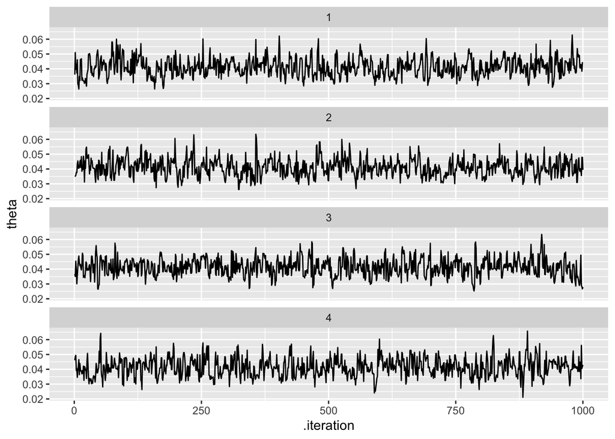

```r
theta_tbl <- virginia_model$draws(c("theta", "theta_inicial")) %>% as_draws_df()
ggplot(theta_tbl, aes(x = .iteration, y = theta)) +
  geom_line() +
  facet_wrap(~.chain, ncol = 1)
```

```r
# Idaho
state_data <- data %>% filter(state == "idaho")
idaho_model <- model_$sample(
  data = list(n=state_data$n,y=state_data$very_liberal),
  chains = 4,
  refresh = 500,
  seed = 1234
)
```

```
## Running MCMC with 4 sequential chains...
##
## Chain 1 Iteration:    1 / 2000 [  0%]  (Warmup)
## Chain 1 Iteration:  500 / 2000 [ 25%]  (Warmup)
## Chain 1 Iteration: 1000 / 2000 [ 50%]  (Warmup)
## Chain 1 Iteration: 1001 / 2000 [ 50%]  (Sampling)
## Chain 1 Iteration: 1500 / 2000 [ 75%]  (Sampling)
## Chain 1 Iteration: 2000 / 2000 [100%]  (Sampling)
## Chain 1 finished in 0.0 seconds.
## Chain 2 Iteration:    1 / 2000 [  0%]  (Warmup)
## Chain 2 Iteration:  500 / 2000 [ 25%]  (Warmup)
## Chain 2 Iteration: 1000 / 2000 [ 50%]  (Warmup)
## Chain 2 Iteration: 1001 / 2000 [ 50%]  (Sampling)
## Chain 2 Iteration: 1500 / 2000 [ 75%]  (Sampling)
## Chain 2 Iteration: 2000 / 2000 [100%]  (Sampling)
## Chain 2 finished in 0.0 seconds.
## Chain 3 Iteration:    1 / 2000 [  0%]  (Warmup)
## Chain 3 Iteration:  500 / 2000 [ 25%]  (Warmup)
## Chain 3 Iteration: 1000 / 2000 [ 50%]  (Warmup)
## Chain 3 Iteration: 1001 / 2000 [ 50%]  (Sampling)
## Chain 3 Iteration: 1500 / 2000 [ 75%]  (Sampling)
## Chain 3 Iteration: 2000 / 2000 [100%]  (Sampling)
## Chain 3 finished in 0.0 seconds.
## Chain 4 Iteration:    1 / 2000 [  0%]  (Warmup)
## Chain 4 Iteration:  500 / 2000 [ 25%]  (Warmup)
## Chain 4 Iteration: 1000 / 2000 [ 50%]  (Warmup)
## Chain 4 Iteration: 1001 / 2000 [ 50%]  (Sampling)
## Chain 4 Iteration: 1500 / 2000 [ 75%]  (Sampling)
## Chain 4 Iteration: 2000 / 2000 [100%]  (Sampling)
## Chain 4 finished in 0.0 seconds.
##
## All 4 chains finished successfully.
## Mean chain execution time: 0.0 seconds.
## Total execution time: 0.5 seconds.
```

```r
idaho_model$summary()
```

```
## # A tibble: 3 × 10
##   variable          mean   median     sd    mad       q5      q95  rhat ess_bulk
##   <chr>            <dbl>    <dbl>  <dbl>  <dbl>    <dbl>    <dbl> <dbl>    <dbl>
## 1 lp__          -79.8    -79.5    0.728  0.324  -81.2    -79.3     1.00    2051.
## 2 theta           0.0719   0.0708 0.0148 0.0149   0.0496   0.0977  1.00    1268.
## 3 theta_inicial   0.0478   0.0463 0.0166 0.0162   0.0234   0.0772  1.00    3949.
## # ℹ 1 more variable: ess_tail <dbl>
```

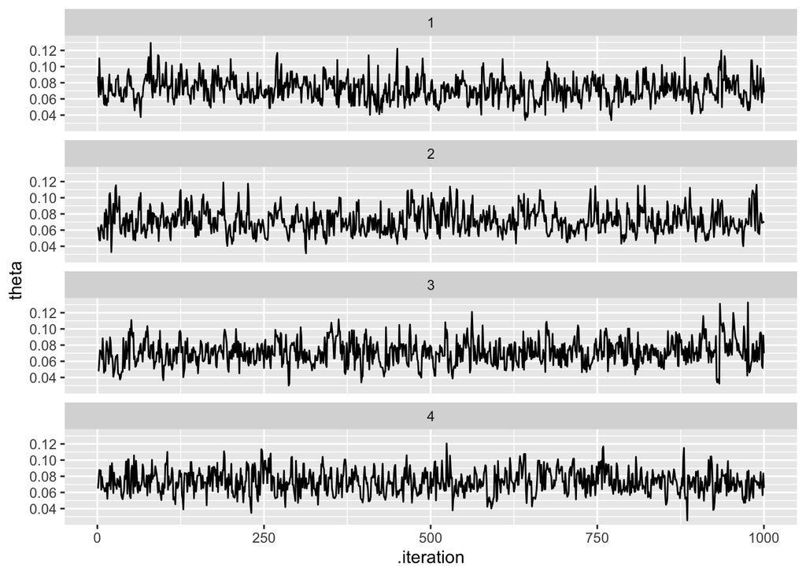

```r
theta_tbl <- idaho_model$draws(c("theta", "theta_inicial")) %>% as_draws_df()
ggplot(theta_tbl, aes(x = .iteration, y = theta)) +
  geom_line() +
  facet_wrap(~.chain, ncol = 1)
```

**En conclusión, tanto para Idaho como para Virginia, los valores de R-hat cercanos a 1 indican una convergencia sólida de las cadenas MCMC y estimaciones de parámetros confiables. Además, los altos valores de ess_bulk y ess_tail en ambos estados sugieren una gran cantidad de muestras efectivas, respaldando resultados estadísticamente precisos.**

- Utiliza la media posterior de cada estado como estimador puntual y repite las gráficas del inciso anterior.

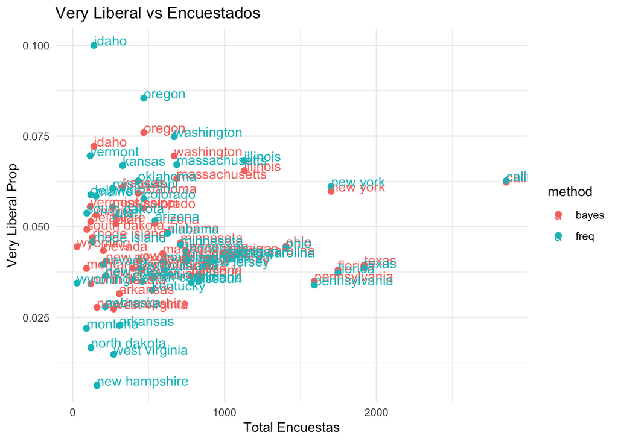

```r
result_bayes <- posterior_by_state %>%
  mutate(method = 'bayes') %>%
  rename(mle = posterior) %>%
  select(state, mle, method) %>%
  inner_join(data %>% select(c('state','n')), by = "state") %>%
  inner_join(election_result %>% select(c('state','vote_Obama_pct')), by = "state") #%>%

result_freq <- data %>%
  mutate(method = 'freq') %>%
  rename(mle = p) %>%
  select(state, mle, method, n) %>%
  inner_join(election_result %>% select(c('state','vote_Obama_pct')), by = "state")

final_result <- bind_rows(result_bayes, result_freq)

ggplot(final_result, aes(x=n, y=mle, color=method)) +
  geom_point(size = 2) +
  geom_text(aes(label=state), hjust=0, vjust=0) +
  labs(title = "Very Liberal vs Encuestados",
       x = "Total Encuestas",
       y = "Very Liberal Prop") +
  theme_minimal()
```

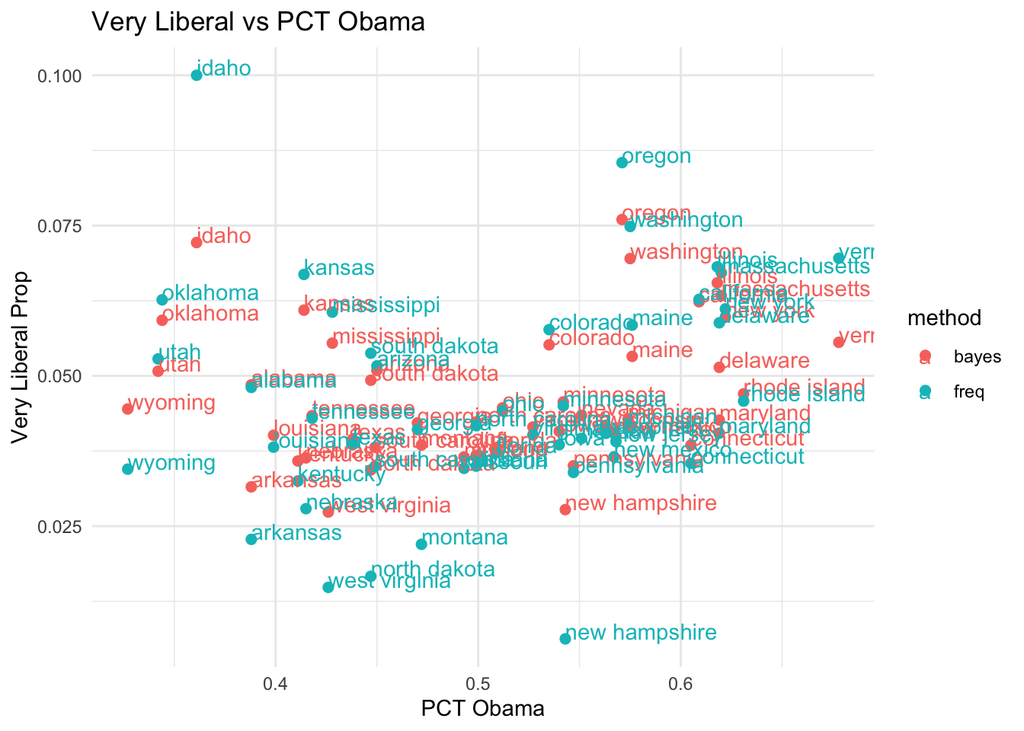

```r
ggplot(final_result, aes(x=vote_Obama_pct, y=mle, color=method)) +
  geom_point(size = 2) +
  geom_text(aes(label=state), hjust=0, vjust=0) +
  labs(title = "Very Liberal vs PCT Obama",
       x = "PCT Obama",
       y = "Very Liberal Prop") +
  theme_minimal()
```

**El método bayesiano muestra una proporción más controlada de individuos muy liberales en cada estado, en contraste con el enfoque frecuentista, donde se observa una dispersión mayor.**

**Nota:** En problemas como este, donde estamos estimando un parámetro para cada grupo (estado e nuestro caso) podemos optar por un modelo jerárquico, en donde la distribución de las $\theta_j$ no esta dada por la incial sino que se modela con un nivel adicional, cuyos parámetros se estiman con los datos y tienen a su vez una distribución incial:

$$y_j|\theta_j \sim Binomial(n_j,
\theta_j)$$

$$\theta_j \sim Beta(\alpha, \beta)$$

$$\alpha \sim g(a_o), \beta \sim
f(b_0)$$

donde $g(a_0)$ y $f(b_0)$ son las inciales seleccionadas con conocimiento experto.